# Homework 3 Solutions

Elijah Hall, EH2794

2018-07-17

```r
library(tidyverse)
library("MASS", lib.loc = "C:/Program Files/R/R-3.5.0/library")
library(GGally)
library(moments)
library(nortest)
library(e1071)
library(data.table)
library(ggdendro)
library(dendextend)
library(ROCR)
library(car)
library(class)

# library(datasets)

# #library(ggplot2) #library(dplyr) library(scales)
# library(reshape2) library(flexclust) #library(tidyr)
# library(plotly) library(Hmisc) library(Sleuth2)
# library(grid) library(gridExtra) library(kableExtra)
```

```r
# find optimal cutoff rate,
# https://www.r-bloggers.com/a-small-introduction-to-the-rocr-package/
opt.cut = function(perf, pred) {
    cut.ind = mapply(FUN = function(x, y, p) {
        d = (x - 0)^2 + (y - 1)^2
        ind = which(d == min(d))
        c(sensitivity = y[[ind]], specificity = 1 - x[[ind]],
            cutoff = p[[ind]])
    }, perf@x.values, perf@y.values, pred@cutoffs)
}
```

```r
theme_update(plot.title = element_text(hjust = 0.5))

mytheme <- theme_bw() + theme(panel.border = element_blank(),
    axis.line = element_line(color = "black"), plot.background = element_blank(),
    panel.grid.major = element_blank(), panel.grid.minor = element_blank(),
    plot.title = element_text(hjust = 0.5), axis.title.x = element_text(color = "black",
        size = 10), axis.title.y = element_text(color = "black",
        size = 10))
```

```r
data(cats)
cig_sales <- fread("cig_sales.txt")
echogen <- fread("echogen.txt")
data(iris)
```

```r
cats$Sex.Bin <- as.character(cats$Sex)
cats$Sex.Bin[cats$Sex == "M"] <- 1
cats$Sex.Bin[cats$Sex == "F"] <- 0
cats$Sex.Bin <- as.factor(cats$Sex.Bin)

echogen <- echogen[sample(x = 1:nrow(echogen)), ]
```

## Question #1 Linear Regression, Logistic Regression: Load the *cats* dataset from the **MASS** library. This dataset includes the body and heart rates of both male and female adult domestic cats.

### 1a. Determine the size of dataset, the missing rows, and randomize data.

```r
head(cats)
```

```
  Sex Bwt Hwt Sex.Bin
1   F 2.0 7.0       0
2   F 2.0 7.4       0
3   F 2.0 9.5       0
4   F 2.1 7.2       0
5   F 2.1 7.3       0
6   F 2.1 7.6       0
```

```r
str(cats)
```

```
'data.frame':   144 obs. of  4 variables:
 $ Sex    : Factor w/ 2 levels "F","M": 1 1 1 1 1 1 1 1 1 1 ...
 $ Bwt    : num  2 2 2 2.1 2.1 2.1 2.1 2.1 2.1 2.1 ...
 $ Hwt    : num  7 7.4 9.5 7.2 7.3 7.6 8.1 8.2 8.3 8.5 ...
 $ Sex.Bin: Factor w/ 2 levels "0","1": 1 1 1 1 1 1 1 1 1 1 ...
```

```r
summary(cats)
```

```
 Sex         Bwt             Hwt        Sex.Bin
 F:47   Min.   :2.000   Min.   : 6.30   0:47
 M:97   1st Qu.:2.300   1st Qu.: 8.95   1:97
        Median :2.700   Median :10.10
        Mean   :2.724   Mean   :10.63
        3rd Qu.:3.025   3rd Qu.:12.12
        Max.   :3.900   Max.   :20.50
```

```r
# create random index
idx <- sample(nrow(cats))

# reorder dataset
cats <- cats[idx, ]
```

There are 144 cats in this data set. Bwt I assume is the body weight and Hwt I assume is the heart weight. The problem is that the values are not what I would expect. I found the units for these two variables online. Body weight is measured in kilograms(Kg) while heart weight is measured in grams(g).

### 1b. Create a scatterplot of heart weight versus body weight. Explain if simple linear regression may be a good fit. How does the data satisfy the assumptions of linear regression?

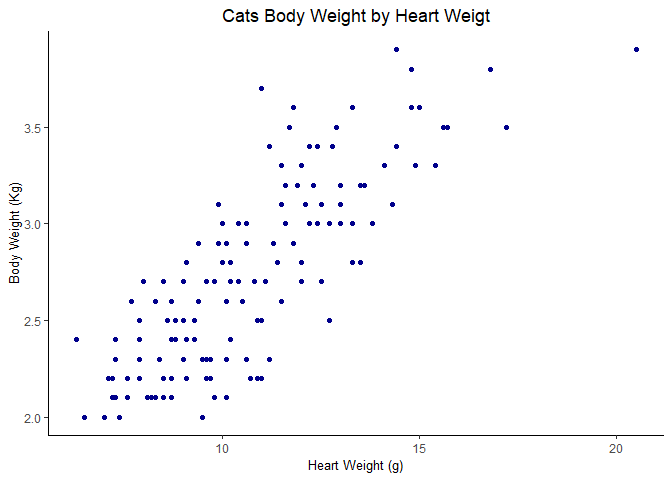

```r
ggplot(cats, aes(x = Hwt, y = Bwt)) + geom_point(col = "darkblue") +
    mytheme + labs(title = "Cats Body Weight by Heart Weigt",
    x = "Heart Weight (g)", y = "Body Weight (Kg)")
```

Looking at the plot of the data appears to be linear. However we know that there is a categorical variable of Sex and the two groups are likely to be different.

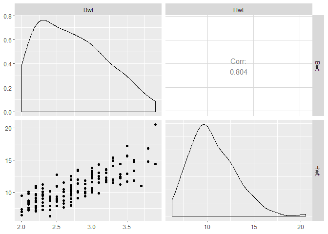

```r
ggpairs(cats, columns = c("Bwt", "Hwt"))
```

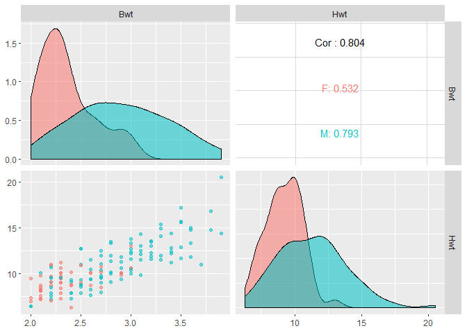

```r
ggpairs(cats, columns = c("Bwt", "Hwt"), mapping = ggplot2::aes(colour = cats$Sex,
    alpha = 0.8))
```

Inspecting the five asusmptions of linear regression. 1) The data appears to be linear in realationship as a whole with a correlation of .8, however when you consider the different sexes that perceptoion changes a bit.

```r
Bwt_F <- cats %>% as.data.frame() %>% filter(Sex == "F") %>%
    dplyr::select(Bwt) %>% scale()
Bwt_M <- cats %>% as.data.frame() %>% filter(Sex == "M") %>%
    dplyr::select(Bwt) %>% scale()

#----Assumption 2----
# testing nromal assumptions
# https://stats.stackexchange.com/questions/52293/r-qqplot-how-to-see-whether-data-are-normally-distributed/52295

# skewness and kurtosis, they should be around (0,3)
skewness(Bwt_F)
```

```
[1] 0.869862
```

```r
kurtosis(Bwt_F)
```

```
[1] -0.2118201
```

```r
skewness(Bwt_M)
```

```
[1] 0.1289608
```

```r
kurtosis(Bwt_M)
```

```
[1] -0.8019604
```

```r
# Shapiro-Wilks test
shapiro.test(Bwt_F)
```

```
    Shapiro-Wilk normality test

data:  Bwt_F
W = 0.89096, p-value = 0.0003754
```

```r
# Kolmogorov-Smirnov test
ks.test(Bwt_F, "pnorm", mean(Bwt_F), sqrt(var(Bwt_F)))
```

```
    One-sample Kolmogorov-Smirnov test

data:  Bwt_F
D = 0.22436, p-value = 0.01762
alternative hypothesis: two-sided
```

```r
# Anderson-Darling test
ad.test(Bwt_F)
```

```
    Anderson-Darling normality test

data:  Bwt_F
A = 1.8322, p-value = 9.333e-05
```

```r
# Shapiro-Wilks test
shapiro.test(Bwt_M)
```

```
    Shapiro-Wilk normality test

data:  Bwt_M
W = 0.97883, p-value = 0.119
```

```r
# Kolmogorov-Smirnov test
ks.test(Bwt_M, "pnorm", mean(Bwt_M), sqrt(var(Bwt_M)))
```

```
    One-sample Kolmogorov-Smirnov test

data:  Bwt_M
D = 0.077981, p-value = 0.5969
alternative hypothesis: two-sided
```

```r
# Anderson-Darling test
ad.test(Bwt_M)
```

```
    Anderson-Darling normality test

data:  Bwt_M
A = 0.50781, p-value = 0.1951
```

Looking at the Q-Q plot will also help determine normality.

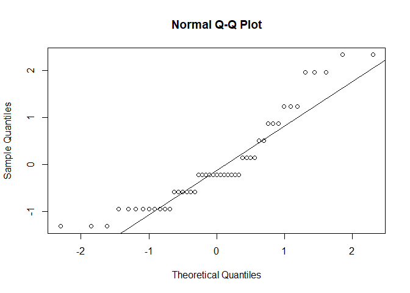

```r
# qq-plot: you should observe a good fit of the straight
# line
qqnorm(Bwt_F)
qqline(Bwt_F)
```

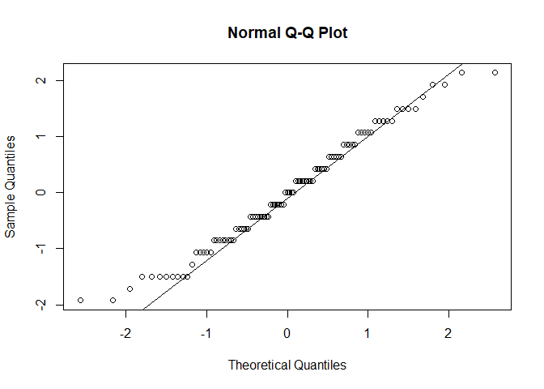

```r
qqnorm(Bwt_M)
qqline(Bwt_M)
```

```r
#----Assumption 4----

mod <- lm(Hwt ~ Bwt, data = cats)
summary(mod$residuals)
```

```
    Min.  1st Qu.   Median     Mean  3rd Qu.     Max.
-3.56937 -0.96341 -0.09212  0.00000  1.04255  5.12382
```

```r
durbinWatsonTest(lm(Hwt ~ Bwt, data = cats))
```

```
 lag Autocorrelation D-W Statistic p-value
   1     -0.01422557      2.027664    0.83
 Alternative hypothesis: rho != 0
```

3. Since there is only one independent variable assumption 3 of little or no multicolinearity doesn’t need to be proven.
4. As for auto correlation the Durbin Watson Test computes residual autocorrelations from the linear model. The p-value is very high meaning we don’t reject the null hypothesis of no serial correlation.

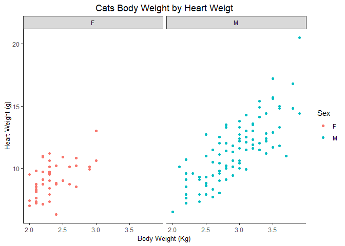

```r
ggplot(cats, aes(x = Bwt, y = Hwt, col = Sex)) + geom_point() +
    mytheme + facet_wrap(~Sex) + labs(title = "Cats Body Weight by Heart Weigt",
    y = "Heart Weight (g)", x = "Body Weight (Kg)")
```

5. The last assumption of homoscedasticity can be checked visually. We see that the plots by sex are both homoskedastic, meaning that the spread across the data remains constent as you move from left to right.

### 1c. Write out the linear regression equation of heart weight onto body weight and interpret the equation. Explain how the coefficients and the overall regression are significant. Find and interpret the residual standard error. Find and interpret the coefficient of determinations.

The linear equation for heart weight onto body weight is $Hwt = \alpha + \beta \times Bwt + \varepsilon$. The alpha beta is the intercept term which can be interpreted as the Heart weight at the time the body develops, however this is difficult to accept since all cells develop through a natural process where the heart and body will start at near 0. Beta is the amount of Heart weight in grams that increases for every additional kilogram in body weight. The error term is the residual value and the amount of heart weight not explained by the linear model for each observation.

```r
summary(mod)
```

```
Call:
lm(formula = Hwt ~ Bwt, data = cats)

Residuals:
    Min      1Q  Median      3Q     Max
-3.5694 -0.9634 -0.0921  1.0426  5.1238

Coefficients:
            Estimate Std. Error t value Pr(>|t|)
(Intercept)  -0.3567     0.6923  -0.515    0.607
Bwt           4.0341     0.2503  16.119   <2e-16 ***
---
Signif. codes:  0 '***' 0.001 '**' 0.01 '*' 0.05 '.' 0.1 ' ' 1

Residual standard error: 1.452 on 142 degrees of freedom
Multiple R-squared:  0.6466,    Adjusted R-squared:  0.6441
F-statistic: 259.8 on 1 and 142 DF,  p-value: < 2.2e-16
```

### 1d. Splitting 70% of the data for the training data. Identify how many observations the training and testing datasets have.

```r
set.seed(123)
train <- sample(1:nrow(cats), size = round(0.7 * nrow(cats)))
```

The training set has 101 observations while the testing set has 43. There are no missing values in the data.

### 1e. Do the logistic regression and estimate the success rate of prediction.

```r
mod1 <- glm(formula = Sex.Bin ~ Bwt + Hwt, family = binomial(),
    data = cats[train, 2:4])
summary(mod1)
```

```
Call:
glm(formula = Sex.Bin ~ Bwt + Hwt, family = binomial(), data = cats[train,
    2:4])

Deviance Residuals:
    Min       1Q   Median       3Q      Max
-2.2241  -0.7269   0.2736   0.6238   2.1273

Coefficients:
             Estimate Std. Error z value Pr(>|z|)
(Intercept) -10.98372    2.26039  -4.859 1.18e-06 ***
Bwt           4.29283    1.26369   3.397 0.000681 ***
Hwt           0.03774    0.22610   0.167 0.867444
---
Signif. codes:  0 '***' 0.001 '**' 0.01 '*' 0.05 '.' 0.1 ' ' 1

(Dispersion parameter for binomial family taken to be 1)

    Null deviance: 132.709  on 100  degrees of freedom
Residual deviance:  87.337  on  98  degrees of freedom
AIC: 93.337

Number of Fisher Scoring iterations: 5
```

```r
pred_mod1 <- predict(object = mod1, newdata = cats[-train,
    2:4], type = "response")

error <- cats[-train, 4] %>% as.character() %>% as.numeric() -
    pred_mod1

RMSE <- sqrt(mean(error^2))
# paste('RMSE =', round(RMSE, digits = 3))


# miss classification
accuracy <- mean(cats[-train, 4] == ifelse(pred_mod1 > 0.5,
    1, 0))
# paste('Accuracy =', round(accuracy, digits = 3))
```

It should be noted that the p-value for Hwt is not significant. This is due to its strong collinearity with Bwt. The RMSE = 0.443 and Accuracy = 0.744.

### 1f. How would the result change if you use just the body weight?

```r
mod2 <- glm(formula = Sex.Bin ~ Bwt, family = binomial(),
    data = cats[train, 2:4])
summary(mod2)
```

```
Call:
glm(formula = Sex.Bin ~ Bwt, family = binomial(), data = cats[train,
    2:4])

Deviance Residuals:
    Min       1Q   Median       3Q      Max
-2.2044  -0.7200   0.2791   0.6496   2.1077

Coefficients:
            Estimate Std. Error z value Pr(>|z|)
(Intercept) -10.9942     2.2591  -4.867 1.14e-06 ***
Bwt           4.4439     0.8918   4.983 6.26e-07 ***
---
Signif. codes:  0 '***' 0.001 '**' 0.01 '*' 0.05 '.' 0.1 ' ' 1

(Dispersion parameter for binomial family taken to be 1)

    Null deviance: 132.709  on 100  degrees of freedom
Residual deviance:  87.364  on  99  degrees of freedom
AIC: 91.364

Number of Fisher Scoring iterations: 5
```

```r
pred_mod2 <- predict(object = mod2, newdata = cats[-train,
    2:4], type = "response")

error <- cats[-train, 4] %>% as.character() %>% as.numeric() -
    pred_mod2

RMSE2 <- sqrt(mean(error^2))
RMSE2
```

```
[1] 0.4429439
```

```r
# miss classification
accuracy2 <- mean(cats[-train, 4] == ifelse(pred_mod2 >
    0.5, 1, 0))
accuracy2
```

```
[1] 0.744186
```

The estimates for the models are different however the RMSE and accuracy of both models are not, RMSE = 0.443 and Accuracy = 0.744. The reason for this is assumption 3 of a linear model. The two independent variables Bwt and Hwt have a strong correlation to eachother. Removing one therefore doesn’t change the overall effectiveness of the model but gives better and more accurate estimates.

## Question #2 Multiple Linear Regression, Hierarchy Clustering: Find the file called *cig_sales.txt* under **HW#3** and load it. Using the file, we can explore cigarette sales as a function of various demographic information.

### 2a. Discuss about the data: verify qualitative and quantitative variables, determine the highest and lowest sales state, and estimate the average and standard deviation of age, price, and income. Identify any correlated variables with sales from a scatterplot matrix.

```r
summary(cig_sales)
```

```
    State                Age              HS            Income
 Length:51          Min.   :22.90   Min.   :37.80   Min.   :2626
 Class :character   1st Qu.:26.40   1st Qu.:48.30   1st Qu.:3271
 Mode  :character   Median :27.40   Median :53.30   Median :3751
                    Mean   :27.47   Mean   :53.15   Mean   :3764
                    3rd Qu.:28.75   3rd Qu.:59.10   3rd Qu.:4116
                    Max.   :32.30   Max.   :67.30   Max.   :5079
     Black            Female          Price           Sales
 Min.   : 0.200   Min.   :45.70   Min.   :29.00   Min.   : 65.5
 1st Qu.: 1.600   1st Qu.:50.75   1st Qu.:34.70   1st Qu.:105.3
 Median : 6.000   Median :51.10   Median :38.90   Median :119.0
 Mean   : 9.992   Mean   :50.95   Mean   :38.07   Mean   :121.5
 3rd Qu.:13.550   3rd Qu.:51.50   3rd Qu.:41.35   3rd Qu.:124.5
 Max.   :71.100   Max.   :53.50   Max.   :45.50   Max.   :265.7
```

```r
# high and low sales
high <- cig_sales[cig_sales$Sales == max(cig_sales$Sales),
    ]
low <- cig_sales[cig_sales$Sales == min(cig_sales$Sales),
    ]

# estimate the average and standard deviation of age,
# price, and income
Avg <- cig_sales %>% as.data.frame() %>% dplyr::select(Age,
    Price, Income) %>% summarise_all(mean)
Sd <- cig_sales %>% as.data.frame() %>% dplyr::select(Age,
    Price, Income) %>% summarise_all(sd)

est_df <- rbind(Avg, Sd)
rownames(est_df) <- c("Avg", "StdDev")
kable(est_df)
```

|  | Age | Price | Income |
| --- | --- | --- | --- |
| Avg | 27.466667 | 38.074510 | 3763.7059 |
| StdDev | 1.876983 | 4.128576 | 594.7156 |

**State** is a categorical variable and has all 50 states plus DC. All other variables are quantitative. **Age** range is from 22.90 to 32.30 years which seems very specific and narrow. **HS** appears to be the % of high school graduates by state ranging from 37.8 to 67.30. **Income** is difficult to interpret the units. It appears to be average monthly income in dollars. **Black** appears to be the proportion of african americans in the state. Similarly **Female** is the proporiton of females in the state where $Male = 1 - Female$ is the proportion of males in the state. **Price** is difficult to interpret as well. It might be price per carton since the minimum is much to high for a pack. **Sales** appears to be average sales but is hard to interpret as to whether it is cartons by year, annual $, or packs per person.

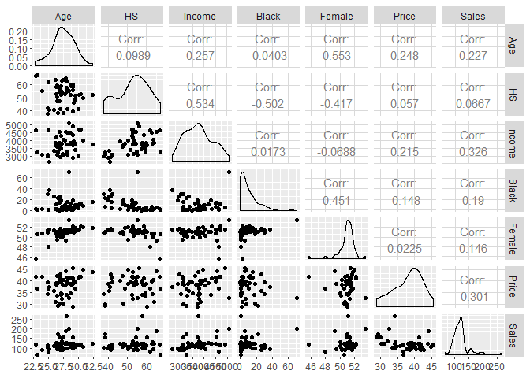

```r
ggpairs(cig_sales[, -1])
```

The correlations with Sales are Age = 0.227, HS = 0.0667, Income = 0.326, Black = 0.19, Female = 0.146, and Price = -0.301. Some of these correlations seem to be pulled by groups of outliers.

### 2b. Do a multiple linear regression using sales as your responsible variable. Discuss how you would treat the State variable. Produce a summary of the fit and interpret the results (e.g., the residual standard error, the overall regression, etc.).

```r
library(caret)
cig_sales$State <- cig_sales$State %>% as.factor()
hep_mod <- train(Sales ~ ., method = "lm", data = cig_sales[,
    -1], trControl = trainControl(method = "LOOCV"))

summary(hep_mod)
```

```
Call:
lm(formula = .outcome ~ ., data = dat)

Residuals:
    Min      1Q  Median      3Q     Max
-48.398 -12.388  -5.367   6.270 133.213

Coefficients:
             Estimate Std. Error t value Pr(>|t|)
(Intercept) 103.34485  245.60719   0.421  0.67597
Age           4.52045    3.21977   1.404  0.16735
HS           -0.06159    0.81468  -0.076  0.94008
Income        0.01895    0.01022   1.855  0.07036 .
Black         0.35754    0.48722   0.734  0.46695
Female       -1.05286    5.56101  -0.189  0.85071
Price        -3.25492    1.03141  -3.156  0.00289 **
---
Signif. codes:  0 '***' 0.001 '**' 0.01 '*' 0.05 '.' 0.1 ' ' 1

Residual standard error: 28.17 on 44 degrees of freedom
Multiple R-squared:  0.3208,    Adjusted R-squared:  0.2282
F-statistic: 3.464 on 6 and 44 DF,  p-value: 0.006857
```

If I were to include **State** as an independent variable, I would want to create 50 binary variables using Washington DC as the reference state. This way the beta would be activated for whichever state the observation is from. The problem with doing that with this data is that we only have one pobservation for each state. If we had previous observations over time this would give us better data to understand the influence of each variable specific to each state.

This linear model as is shows only price to be statistically significant with the intercept being very high. The residual standard error is also very high at 28.17 meaning that about 96% of observations fall between + or - 56.34. This is not very accurate which is also shown in the Multiple R-squared and adusted R-squared of 0.32 and 0.22. These values represent the proportion of variance in the data explained by the model and the same adjusted for multiple predictors respectively. A lot of these variables have strong correlation to eachother which is likely impacting the fit of this model. Even though the model appear to be performing poorly it is still better than an intercept only model which is what the p-value of the model is telling us. Since the p-value is significant we reject the null hypothesis that the data is explained by an intercept only model. A good strategy would be to combine the variables with high correlation to eachother or remove one.

### 2c. What happens to the sales when the price goes up by a dollar per carton.

Sales decrease by 3.25 when price goes up by a dollar per carton.

### 2e. Scale the data and calculate the pairwise distance between observations. Create various dendrograms using complete and average linkage. Cut the dendrogram into groups of 3, 4, 5, and 6. Discuss which is the most appropriate number of groups. Discuss the common features by groups.

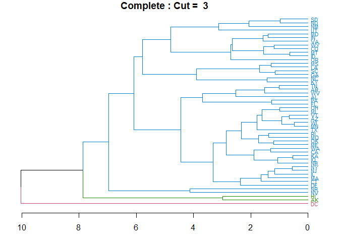

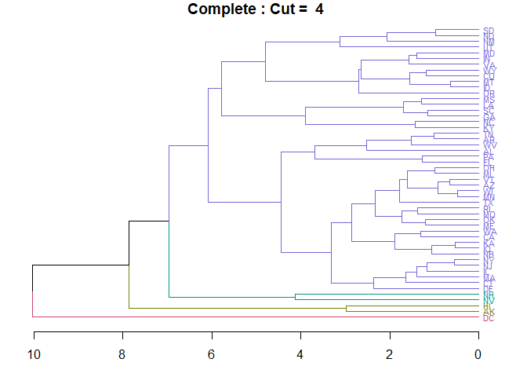

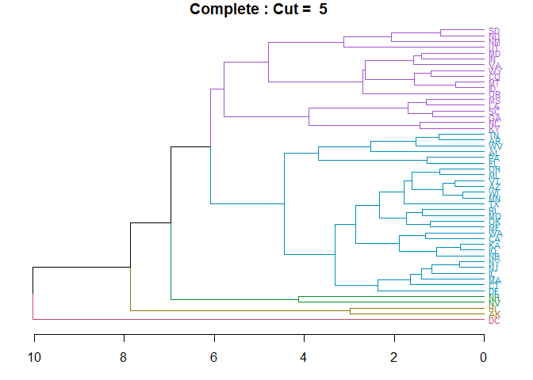

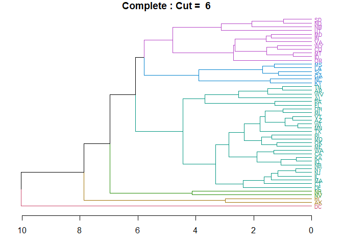

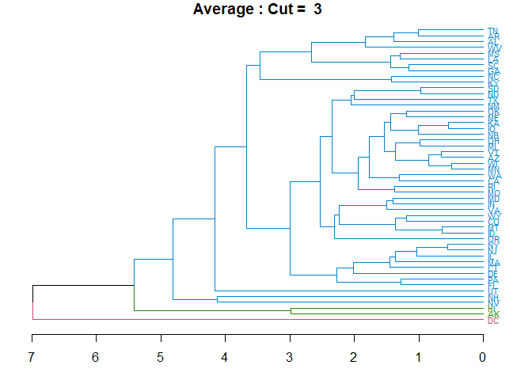

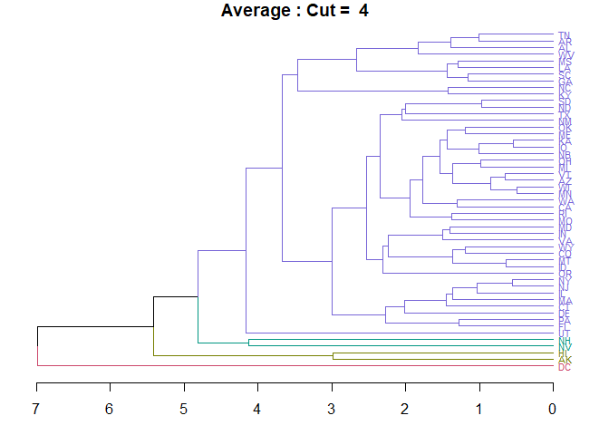

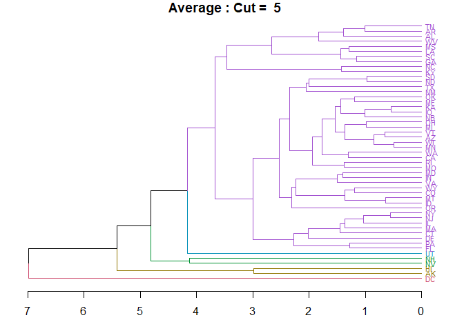

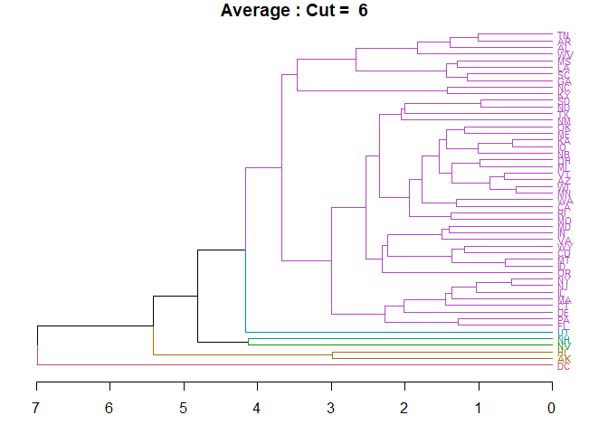

```r
cig_sales_scale <- cig_sales[, -1] %>% as.data.frame()
idx_fac <- cig_sales[, 1] %>% unlist() %>% as.numeric()
rownames(cig_sales_scale) <- levels(cig_sales$State)[idx_fac]

cig_sales_scale <- cig_sales_scale %>% scale() %>% as.data.frame()

cig_sales_dist <- cig_sales_scale %>% dist()


cig_sales_c_hc <- cig_sales_dist %>% hclust(method = "complete")
cig_sales_a_hc <- cig_sales_dist %>% hclust(method = "average")


dens <- list(cig_sales_c_hc, cig_sales_a_hc)
titles <- c("Complete", "Average")

for (i in 1:length(dens)) {
    for (k in 3:6) {
        par(mar = c(3, 1, 1, 2))
        dens[[i]] %>% as.dendrogram %>% set("branches_k_color",
            k = k) %>% set("labels_cex", c(0.7)) %>% set("labels_colors",
            k = k) %>% plot(horiz = T, main = paste(titles[i],
            ": Cut = ", k))
    }
}
```

The **Complete** method appears to cut the groups into larger more informative clusters once you go beyond 4 however Average is mostly grouped into one cluster with only 1 or 2 in the other clusters. I will use a judgemnet call to use the Complete cluster method with 5 clusters, k=5.

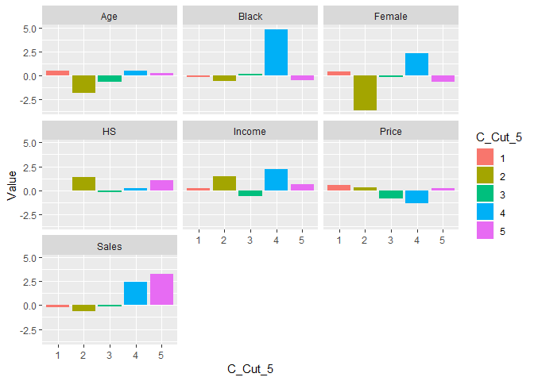

```r
cig_sales_scale$C_Cut_5 <- cig_sales_c_hc %>% cutree(k = 5) %>%
    as.factor()
ag.cols <- c("Age", "HS", "Income", "Black", "Female", "Price",
    "Sales")

temp <- cig_sales_scale %>% group_by(C_Cut_5) %>% dplyr::select(ag.cols) %>%
    summarise_all(mean)
temp <- temp %>% gather(key = "Variable", value = "Value",
    -C_Cut_5)
temp$C_Cut_5 <- as.factor(temp$C_Cut_5)
temp$Variable <- as.factor(temp$Variable)

ggplot(temp, aes(x = C_Cut_5, y = Value, fill = C_Cut_5)) +
    geom_bar(stat = "identity", position = "dodge") + facet_wrap(~Variable)
```

Cluster 4 can be characterized as high income, african amarican women. Cluster 2 can be labled younger, middle class, educated men. Where cluster 4 has the lowest price and second highest sales. Cluster 5 has the highest sales and is second highest in eduction.

## Question #3 KNN, Kmean: Download the file *echogen.txt* from Canvas. These data are from a study evaluating cancer in dogs and can be used to answer the question, *are dogs’ lymph nodes benign or malignant?* The predictors reflect several associated ultrasonography measurements. The study’s objective was to evaluate use of ultrasound to characterize lymph nodes in dogs. The six variables in these data include, Echogen, Flowdist, meanPI, meanRI, Lyadpati, and diagtype. The predictor diagtype is a target indicator variable, where 1 indicates malignant and 0 indicates benign.

```r
summary(echogen)
```

```
    Echogen        Flowdist          meanPI          meanRI
 Min.   :0.00   Min.   :0.0000   Min.   :0.140   Min.   :0.0600
 1st Qu.:0.00   1st Qu.:0.0000   1st Qu.:0.930   1st Qu.:0.5600
 Median :1.00   Median :0.0000   Median :1.130   Median :0.6267
 Mean   :1.26   Mean   :0.4463   Mean   :1.202   Mean   :0.6365
 3rd Qu.:3.00   3rd Qu.:1.0000   3rd Qu.:1.450   3rd Qu.:0.7100
 Max.   :3.00   Max.   :2.0000   Max.   :2.720   Max.   :1.0000
    Lyadpati         diagtype
 Min.   :0.0000   Min.   :0.000
 1st Qu.:0.0000   1st Qu.:0.000
 Median :1.0000   Median :0.000
 Mean   :0.6949   Mean   :0.435
 3rd Qu.:1.0000   3rd Qu.:1.000
 Max.   :1.0000   Max.   :1.000
```

### 3a. Divide these data into a training set (119 rows) and a testing set (58 rows). Remember to randomize your data before you do the split. Perform a logistic regression using the training set. Compute numerical and graphical summaries of the data. What patterns, if any, are present? Which of the predictors, if any, appear to be most important? Compute a confusion matrix and an overall number of correct predictions on the training data. What types of errors were shown in the confusion matrix. (Again, refer to page 145 in ISL for help with confusion matrices.)

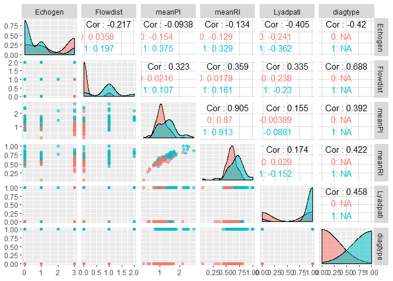

```r
set.seed(123)
train2 <- sample(x = 1:nrow(echogen), size = 119)

ggpairs(echogen, mapping = ggplot2::aes(colour = factor(echogen$diagtype),
    alpha = 0.8))
```

```r
logmod <- glm(formula = diagtype ~ Flowdist + Echogen +
    meanPI, family = "binomial", data = echogen[train2,
    ])
summary(logmod)
```

```
Call:
glm(formula = diagtype ~ Flowdist + Echogen + meanPI, family = "binomial",
    data = echogen[train2, ])

Deviance Residuals:
    Min       1Q   Median       3Q      Max
-2.0026  -0.5004  -0.1300   0.3795   2.5063

Coefficients:
            Estimate Std. Error z value Pr(>|z|)
(Intercept)  -4.4871     1.3198  -3.400 0.000674 ***
Flowdist      3.3028     0.6337   5.212 1.87e-07 ***
Echogen      -0.9822     0.3165  -3.103 0.001914 **
meanPI        3.0978     1.0332   2.998 0.002714 **
---
Signif. codes:  0 '***' 0.001 '**' 0.01 '*' 0.05 '.' 0.1 ' ' 1

(Dispersion parameter for binomial family taken to be 1)

    Null deviance: 163.073  on 118  degrees of freedom
Residual deviance:  74.543  on 115  degrees of freedom
AIC: 82.543

Number of Fisher Scoring iterations: 6
```

The variables that seem to explain the most visually are Flowdist, meanRI, meanPI, and Echogen however meanRI and meanPI have a strong correleation so I will will only use one in my model. The results show all Flowdist, Echogen, and meanPI to be statistically significant with p-values below 1%. The scatter plot matrix also show very specifc boundaries on some variables such as Flowdist v meanPI and Flowdist v Echogen.

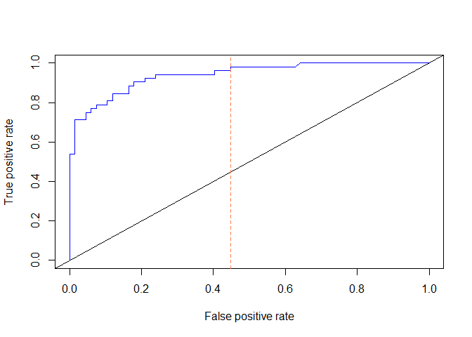

```r
# compute training predictions to set optimal cutoff
logpred <- predict(object = logmod, newdata = echogen[train2,
    ], type = "response")
# create objects to plot ROC and
pr <- prediction(logpred, as.numeric(echogen$diagtype[train2]))
prf <- performance(pr, measure = "tpr", x.measure = "fpr")
# set cutoff
cutoff <- opt.cut(prf, pr)[3, 1]

# plot ROC with cutoff
plot(prf, col = "blue")
abline(a = 0, b = 1)
abline(v = cutoff, lty = 2, col = "coral")
```

```r
# find AUC
auc <- performance(pr, measure = "auc")
auc <- auc@y.values[[1]]

# inspect confusion matrix
confusionMatrix(factor(ifelse(logpred > cutoff, 1, 0)),
    factor(echogen$diagtype[train2]), positive = "1", dnn = c("Prediction",
        "Reference"))
```

```
Confusion Matrix and Statistics

          Reference
Prediction  0  1
         0 59  9
         1  8 43

               Accuracy : 0.8571
                 95% CI : (0.7812, 0.9145)
    No Information Rate : 0.563
    P-Value [Acc > NIR] : 5.697e-12

                  Kappa : 0.709
 Mcnemar's Test P-Value : 1

            Sensitivity : 0.8269
            Specificity : 0.8806
         Pos Pred Value : 0.8431
         Neg Pred Value : 0.8676
             Prevalence : 0.4370
         Detection Rate : 0.3613
   Detection Prevalence : 0.4286
      Balanced Accuracy : 0.8538

       'Positive' Class : 1
```

```r
total_train <- sum(factor(ifelse(logpred > cutoff, 1, 0)) ==
    factor(echogen$diagtype[train2]))
```

### 3b. Run your trained logistic model to the test data. Compute accuracy and a confusion matrix. Again, explain the confusion matrix. How do your results here compare with those on the training set?

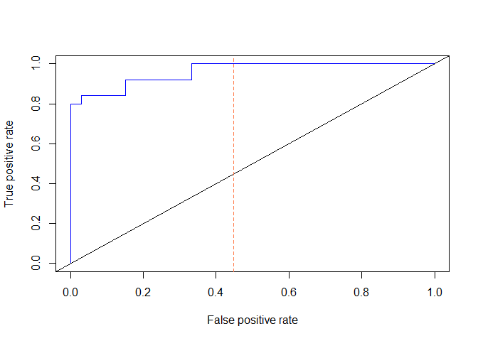

```r
# compute training predictions to set optimal cutoff
logpred2 <- predict(object = logmod, newdata = echogen[-train2,
    ], type = "response")
# create objects to plot ROC and
pr2 <- prediction(logpred2, as.numeric(echogen$diagtype[-train2]))
prf2 <- performance(pr2, measure = "tpr", x.measure = "fpr")

# plot ROC with cutoff
plot(prf2, col = "blue")
abline(a = 0, b = 1)
abline(v = cutoff, lty = 2, col = "coral")
```

```r
# find AUC
auc2 <- performance(pr2, measure = "auc")
auc2 <- auc2@y.values[[1]]

# inspect confusion matrix
confusionMatrix(factor(ifelse(logpred2 > cutoff, 1, 0)),
    factor(echogen$diagtype[-train2]), positive = "1", dnn = c("Prediction",
        "Reference"))
```

```
Confusion Matrix and Statistics

          Reference
Prediction  0  1
         0 28  4
         1  5 21

               Accuracy : 0.8448
                 95% CI : (0.7258, 0.9265)
    No Information Rate : 0.569
    P-Value [Acc > NIR] : 7.081e-06

                  Kappa : 0.6852
 Mcnemar's Test P-Value : 1

            Sensitivity : 0.8400
            Specificity : 0.8485
         Pos Pred Value : 0.8077
         Neg Pred Value : 0.8750
             Prevalence : 0.4310
         Detection Rate : 0.3621
   Detection Prevalence : 0.4483
      Balanced Accuracy : 0.8442

       'Positive' Class : 1
```

```r
total_test <- sum(factor(ifelse(logpred2 > cutoff, 1, 0)) ==
    factor(echogen$diagtype[-train2]))
```

### 3c. Repeat your analysis using **KNN** where k=1, 4, 7, and 10. Calculate the number of misclassifications for each K values.

```r
ks <- c(1, 4, 7, 10)
knn_pred <- c()
missclass <- c()
for (i in 1:length(ks)) {
    knn_pred <- knn(train = echogen[train2, ], test = echogen[-train2,
        ], k = ks[i], cl = echogen$diagtype[train2])
    missclass[i] <- sum(factor(knn_pred) != factor(echogen$diagtype[-train2]))
}
kable(missclass, caption = "Miss Classifications for K= 1,4,7, and 10")
```

Miss Classifications for K= 1,4,7, and 10

| x |
| --- |
| 0 |
| 0 |
| 0 |
| 0 |

For all values I get 0 miss-classifications.

### 3d. Using the **Kmean** clustering method, determine the appropriate number of clusters. Tabulate the number of clusters from 1 to 40 and the total within-cluster variances. Plot the scree plot to visually support your decisions on the cluster number.

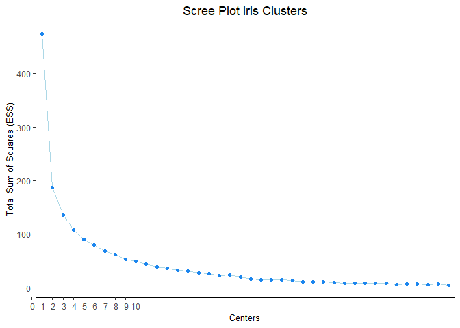

```r
tot.withinss <- c()
for (i in 1:40) {
    echo_km <- kmeans(echogen[, ], centers = i, nstart = 10)
    tot.withinss[i] <- echo_km$tot.withinss
}

scree <- data.frame(1:40, tot.withinss)
names(scree) <- c("centers", "tot.withinss")
ggplot(scree, aes(x = centers, y = tot.withinss)) + mytheme +
    geom_line(col = "lightblue") + geom_point(col = "dodgerblue2") +
    labs(title = "Scree Plot Iris Clusters", x = "Centers",
        y = "Total Sum of Squares (ESS)") + scale_x_discrete(limits = c(0:10))
```

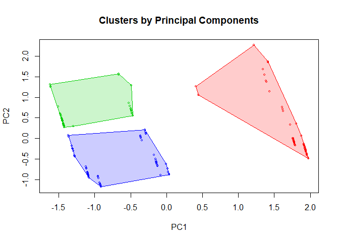

```r
second_d <- c(NA, NA, diff(diff(scree$tot.withinss)))

set_center <- which(max(second_d, na.rm = T) == second_d)

echo_km <- kmeans(echogen[, ], centers = set_center, nstart = 10)

dbscan::hullplot(echogen[, ], echo_km, main = "Clusters by Principal Components")
```

Looking at the scree plot we see that there are some major impovements with the first steps however the marginal improvement decreases rapidly. By maximizing the second derivative I find 3 to be the optimal number of clusters. When I plot these clusters by principal components you can see distinct boundaries by group.

## Question #4 Coding Question: You are trying to cluster the *iris* data set via kmean. Unfortunately, the kmean function is not installed in your R package and you have to write the code from the scratch. Write a function call kmean.alt function that calculates the within cluster variance, aggregates the data by the cluster number, and plots “total within cluster vs. number of cluster”. Verify that your code successfully indicates that the cluster number 3 is the appropriate one.

```r
kmean.alt <- function(data, k = NULL) {
    require(dplyr)
    require(ggplot2)
    require(stats)
    # centers is a list or a single value if centers blank
    # the function will test log(n) s.t. n = nrow(data)
    # centers and return the optimum number of centers
    if (length(k) == 0) {
        start <- 1
        stop <- round(log(nrow(data), 2))
    } else {
        start <- k
        stop <- k
    }

    # declare return variable with cluster variance
    total_within <- vector(mode = "numeric", length = stop)

    num_col <- c()
    for (i in 1:ncol(data)) {
        num_col[i] <- is.numeric(data[, i])
    }
    # run principal component(PC) analysis
    data_pca <- prcomp(data[, num_col])

    v <- summary(data_pca)  #store summary values
    i = 0  # create step variable that will identify number of PC's
    sum_var <- 0  #create stoping variable
    while (sum_var < 0.95) {
        i = i + 1
        sum_var <- sum(v$importance[2, 1:i])
    }

    # keep minimal PC's
    data_pca <- data_pca$x[, 1:i]
    remove(i)


    # iterate over different numbers of clusters
    for (j in start:stop) {

        # assign number of clusters
        centers <- j
        # find numeric columns

        # create starting points for centers
        center_x <- vector(mode = "numeric", length = centers)
        center_y <- vector(mode = "numeric", length = centers)
        for (i in 1:centers) {
            center_x[i] <- sample(data_pca[, 1], size = 1)
            center_y[i] <- sample(data_pca[, 2], size = 1)
        }

        # declare cluster vectors
        cluster <- vector(mode = "integer", length = nrow(data_pca))
        cluster_old <- vector(mode = "integer", length = nrow(data_pca))

        # if j=1 assign all clusters to 1
        if (j != 1) {
            # calculate first iteration of assignments
            for (i in 1:nrow(data_pca)) {
                point_df <- rbind(data_pca[i, ], data.frame(center_x,
                  center_y))
                point_dist <- as.matrix(dist(point_df))
                cluster[i] <- which(min(point_dist[-1, 1]) ==
                  point_dist[, 1]) - 1
            }
        } else {
            cluster <- rep(1, nrow(data))
            cluster_old <- cluster
        }

        # check for exit condition that clusters stop changing
        while (sum(cluster_old == cluster) != length(cluster)) {
            # calculate centers for another iteration
            for (i in 1:centers) {
                center_x[i] <- mean(data_pca[which(cluster ==
                  i), 1], na.rm = T)
                center_y[i] <- mean(data_pca[which(cluster ==
                  i), 2], na.rm = T)
            }
            cluster_old <- cluster
            # calculate cluster assignments
            for (i in 1:nrow(data_pca)) {
                point_df <- rbind(data_pca[i, ], data.frame(center_x,
                  center_y))
                point_dist <- as.matrix(dist(point_df))
                cluster[i] <- which(min(point_dist[-1, 1],
                  na.rm = T) == point_dist[, 1]) - 1
            }
        }

        # assign clusters to dataset
        data$cluster <- cluster

        # calculate within cluster variance
        within_clust <- data %>% group_by(cluster) %>% dplyr::select(which(num_col)) %>%
            summarise_all(.funs = c(var))

        # sum variance for final output
        if (start != stop) {
            total_within[j] <- within_clust[, 2:5] %>% sum()
        } else {
            total_within <- within_clust[, 2:5] %>% sum()
        }

    }

    # create df for scree plot
    scree <- data.frame(centers = start:stop, total_within = total_within)

    # create scree plot
    plot <- ggplot(scree, aes(x = centers, y = total_within)) +
        theme_bw() + theme(panel.border = element_blank(),
        axis.line = element_line(color = "black"), plot.background = element_blank(),
        panel.grid.major = element_blank(), panel.grid.minor = element_blank(),
        plot.title = element_text(hjust = 0.5), axis.title.x = element_text(color = "black",
            size = 10), axis.title.y = element_text(color = "black",
            size = 10)) + geom_line(col = "lightblue") +
        geom_point(col = "dodgerblue2") + labs(title = "Scree Plot Iris Clusters",
        x = "Centers", y = "Total Sum of Squares (ESS)") +
        scale_x_discrete(limits = c(0:10))

    # dake second derivative of total within cluster
    # variance
    second_d <- c(NA, NA, diff(diff(scree$total_within)))

    # find optimal number of clusters by maximizing the
    # second_d
    set_center <- which(max(second_d, na.rm = T) == second_d)

    # return plot, optimal number of clusters and cluster
    # assignments
    return(list(plot, set_center, cluster))

    # ggplot(iris, aes(x=Sepal.Length, y = Petal.Length,
    # color= as.factor(cluster)))+ mytheme+ geom_point()

}
```

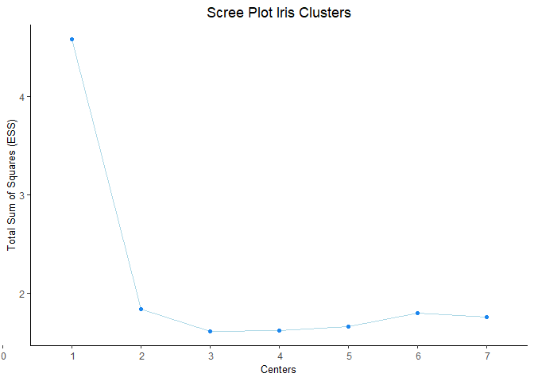

```r
# run function without cluster assignment
test <- kmean.alt(iris)
test[[1]]
```

```r
test[[2]]
```

```
[1] 3
```

The function works and outputs the right values. The scree plot looks good and the optimal value is 3 clusters as expected. Now I want to test this and rerun the function, assuming kmeans still isn’t loaded, and return the optimal cluster assignments.

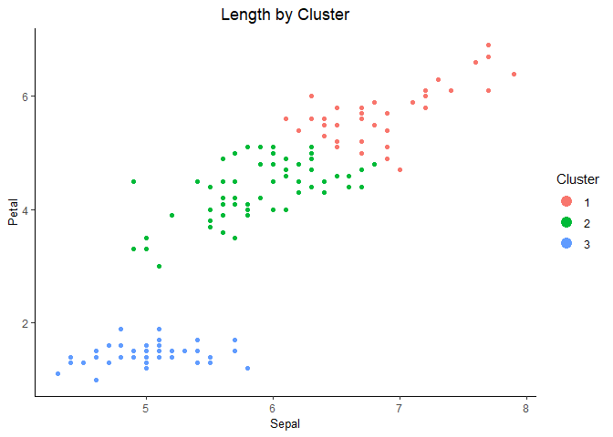

```r
# rerun function with optimal number of clusters and
# visualize on actual data
test2 <- kmean.alt(iris, k = test[[2]])
ggplot(iris, aes(x = Sepal.Length, y = Petal.Length, color = as.factor(test2[[3]]))) +
    mytheme + geom_point() + scale_fill_manual(values = c("#CC6666",
    "#9999CC", "#66CC99")) + labs(title = "Length by Cluster",
    x = "Sepal", y = "Petal") + guides(colour = guide_legend(title = "Cluster",
    override.aes = list(size = 4)))
```

Beautiful! The function works and the clustering is doing what I expected it to do.